# Break-Study-Project

## Data Description

The data for this study was collected by PSY 321 Fall 2024 students and utilized a randomized group design.

The present study’s research question was: Does spending class break “as usual,” in nature, or engaged in movement impact affect and stress? Method: The present study used a group-randomized design to assign twenty-one university classes into three conditions: (1) break as usual, (2) outdoor break, and (3) indoor movement break. From these classes, participants included 374 students who completed an anonymous pre-break survey, 10-minute break, and then post-break survey measuring stress levels and positive/negative affect (20-item Positive and Negative Affect Schedule). Facilitation of break conditions was standardized using slides and a script.

Results: We used a mixed within-between subjects ANOVA to assess the impact of the conditions on participants’ affect and stress scores, across time (pre- and post-intervention). There was a statistically significant increase in positive affect, decrease in negative affect, and decrease in stress when students across all break conditions (p < .001); effect sizes moderate to large (partial eta squared).

Conclusions: Results indicated a significant and meaningful difference in stress and affect across conditions. Our hypothesis – that outdoor and movement breaks would be more beneficial than “break as usual” (i.e., often on screens) – was not supported by the data. Our research provides preliminary evidence for the use of unstructured breaks as a strategy for improving student wellness in the classroom.

## Data Cleaning

In order to assess the data, I needed to import my data from SPSS. I achieved that using the haven package and then I had to make sure that the variables were in the correct format. Adjustments needed to be made based on the names of variables and organization of observations in the dataset. I also made sure that that I did not have missing values in my observations. To create a fidelity check on what activity students spent their breaks on by break conditions, I had to group them by condition, and summarize the data to get an outcome of what each person did based on condition.

## Visualzation 1

Here is a stacked bar plot with eight bars that each indicate the activity each participant did during their break separated by group break condition.

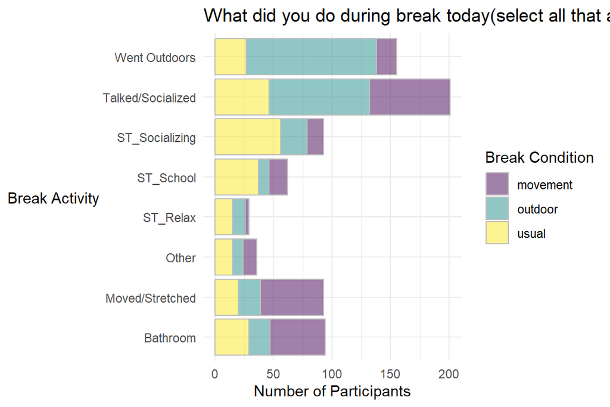

## Visualization 2

Here is a stacked bar plot with eight bars that each indicate the activity each participant usually does during their break separated by group break condition.

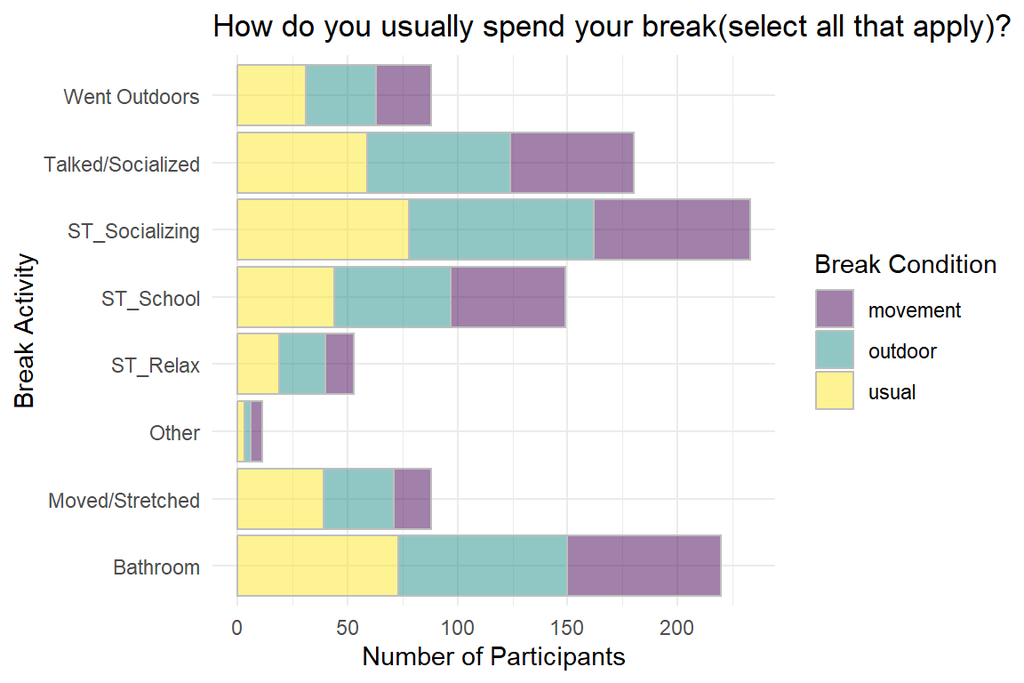